# Peer-graded Assignment：Course Project 1

Chia Yu,Tsai

2016年10月22日

```r
library(ggplot2)
```

# Loading and preprocessing the data

## 1.Load the data (i.e. read.csv())

```r
setwd("F:/coursera/repdata_2Fdata")
activity=read.csv("activity.csv",stringsAsFactors = F)
```

## 2.Process/transform the data (if necessary) into a format suitable for your analysis

```r
str(activity)
```

```
## 'data.frame':    17568 obs. of  3 variables:
##  $ steps   : int  NA NA NA NA NA NA NA NA NA NA ...
##  $ date    : chr  "2012-10-01" "2012-10-01" "2012-10-01" "2012-10-01" ...
##  $ interval: int  0 5 10 15 20 25 30 35 40 45 ...
```

```r
head(activity)
```

```
##   steps       date interval
## 1    NA 2012-10-01        0
## 2    NA 2012-10-01        5
## 3    NA 2012-10-01       10
## 4    NA 2012-10-01       15
## 5    NA 2012-10-01       20
## 6    NA 2012-10-01       25
```

```r
summary(activity)
```

```
##      steps            date              interval
##  Min.   :  0.00   Length:17568       Min.   :   0.0
##  1st Qu.:  0.00   Class :character   1st Qu.: 588.8
##  Median :  0.00   Mode  :character   Median :1177.5
##  Mean   : 37.38                      Mean   :1177.5
##  3rd Qu.: 12.00                      3rd Qu.:1766.2
##  Max.   :806.00                      Max.   :2355.0
##  NA's   :2304
```

We have to let the date variable readable to the computer.

```r
activity$date=as.Date(activity$date,"%Y-%m-%d")
```

# What is mean total number of steps taken per day?

## 1.Calculate the total number of steps taken per day

```r
TotalSteps=aggregate(activity$steps, by=list(activity$date), FUN=sum)
dimnames(TotalSteps)[[2]]=c("date","Steps")
(TotalSteps=TotalSteps[complete.cases(TotalSteps),])
```

```
##          date Steps
## 2  2012-10-02   126
## 3  2012-10-03 11352
## 4  2012-10-04 12116
## 5  2012-10-05 13294
## 6  2012-10-06 15420
## 7  2012-10-07 11015
## 9  2012-10-09 12811
## 10 2012-10-10  9900
## 11 2012-10-11 10304
## 12 2012-10-12 17382
## 13 2012-10-13 12426
## 14 2012-10-14 15098
## 15 2012-10-15 10139
## 16 2012-10-16 15084
```

[output cut: 39 more lines]

## 2.If you do not understand the difference between a histogram and a barplot, research the difference between them. Make a histogram of the total number of steps taken each day

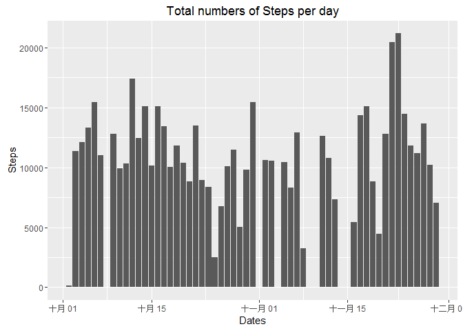

```r
ggplot(TotalSteps, aes(x=date, y=Steps))+
        geom_bar(stat="identity")+ xlab("Dates")+ ylab("Steps")+
        labs(title= "Total numbers of Steps per day")
```

##3.Calculate and report the mean and median of the total number of steps taken per day

```r
mean(TotalSteps$Steps)
```

```
## [1] 10766.19
```

```r
median(TotalSteps$Steps)
```

```
## [1] 10765
```

# What is the average daily activity pattern?

## 1.Make a time series plot (i.e. type = “l”) of the 5-minute interval (x-axis) and the average number of steps taken, averaged across all days (y-axis)

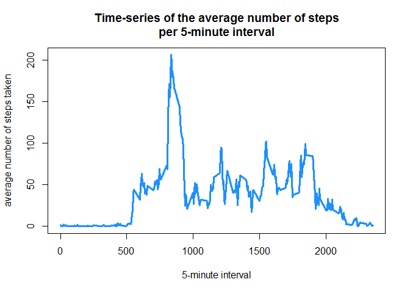

```r
int <- aggregate(activity$steps, by=list(activity$interval),
                       FUN=mean, na.rm=TRUE)
dimnames(int)[[2]]=c("interval","mean")
plot(x=int$interval,y=int$mean,
     type="l", col="dodgerblue",
     lwd=3,
     xlab="5-minute interval",
     ylab="average number of steps taken",
     main="Time-series of the average number of steps\nper 5-minute interval")
```

##2.Which 5-minute interval, on average across all the days in the dataset, contains the maximum number of steps?

```r
int$interval[which(int$mean==max(int$mean))]
```

```
## [1] 835
```

# Imputing missing values

## 1.Calculate and report the total number of missing values in the dataset (i.e. the total number of rows with NAs)

```r
table(complete.cases(activity))[1]
```

```
## FALSE
##  2304
```

## 2.Devise a strategy for filling in all of the missing values in the dataset. The strategy does not need to be sophisticated. For example, you could use the mean/median for that day, or the mean for that 5-minute interval, etc.

```r
x=merge(activity[!complete.cases(activity),],int)
x=x[order(x[,3],x[,1]),]
head(x)
```

```
##    interval steps       date      mean
## 1         0    NA 2012-10-01 1.7169811
## 10        5    NA 2012-10-01 0.3396226
## 17       10    NA 2012-10-01 0.1320755
## 29       15    NA 2012-10-01 0.1509434
## 33       20    NA 2012-10-01 0.0754717
## 45       25    NA 2012-10-01 2.0943396
```

```r
head(activity[!complete.cases(activity),])
```

```
##   steps       date interval
## 1    NA 2012-10-01        0
## 2    NA 2012-10-01        5
## 3    NA 2012-10-01       10
## 4    NA 2012-10-01       15
## 5    NA 2012-10-01       20
## 6    NA 2012-10-01       25
```

```r
activity[!complete.cases(activity),]$steps=x$mean
head(activity)
```

```
##       steps       date interval
## 1 1.7169811 2012-10-01        0
## 2 0.3396226 2012-10-01        5
## 3 0.1320755 2012-10-01       10
## 4 0.1509434 2012-10-01       15
## 5 0.0754717 2012-10-01       20
## 6 2.0943396 2012-10-01       25
```

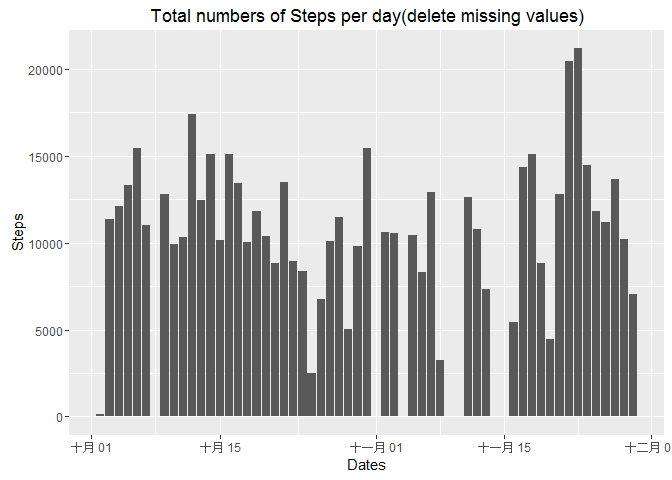

```r
TotalSteps_noNA=aggregate(activity$steps, by=list(activity$date), FUN=sum)
dimnames(TotalSteps_noNA)[[2]]=c("date","Steps")
ggplot(TotalSteps, aes(x=date, y=Steps))+
        geom_bar(stat="identity")+ xlab("Dates")+ ylab("Steps")+
        labs(title= "Total numbers of Steps per day(delete missing values)")
```

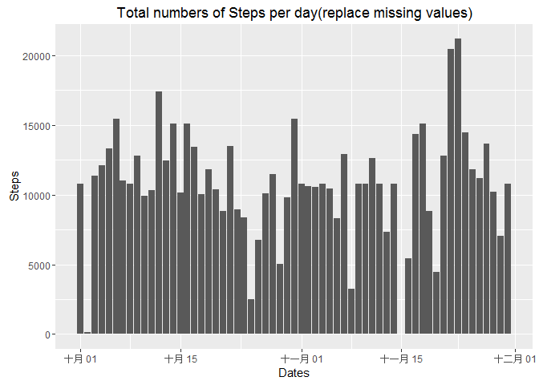

```r
ggplot(TotalSteps_noNA, aes(x=date, y=Steps))+
        geom_bar(stat="identity")+ xlab("Dates")+ ylab("Steps")+
        labs(title= "Total numbers of Steps per day(replace missing values)")
```

## 1.Create a new factor variable in the dataset with two levels – “weekday” and “weekend” indicating whether a given date is a weekday or weekend day.

```r
activity$week=ifelse(weekdays(activity$date) == "星期六" | weekdays(activity$date) == "星期日", "weekend", "weekday")
table(activity$week)
```

```
##
## weekday weekend
##   12960    4608
```

## 2.Make a panel plot containing a time series plot (i.e. type = “l”) of the 5-minute interval (x-axis) and the average number of steps taken, averaged across all weekday days or weekend days (y-axis). The plot should look something like the following, which was created using simulated data:

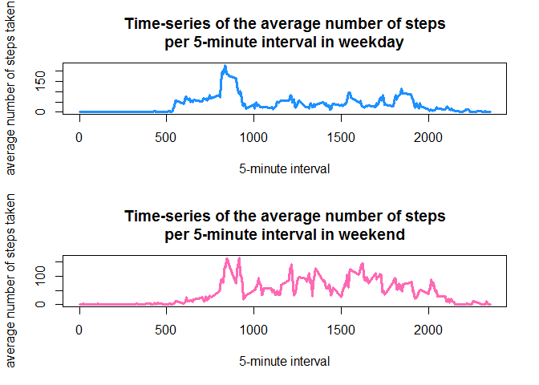

```r
par(mfrow = c(2, 1))
weekday=subset(activity,week=="weekday")
int1 <- aggregate(weekday$steps, by=list(weekday$interval),
                       FUN=mean, na.rm=TRUE)
dimnames(int1)[[2]]=c("interval","mean")
weekend=subset(activity,week=="weekend")
int2 <- aggregate(weekend$steps, by=list(weekend$interval),
                       FUN=mean, na.rm=TRUE)
dimnames(int2)[[2]]=c("interval","mean")
plot(x=int1$interval,y=int1$mean,
     type="l", col="dodgerblue",
     lwd=3,
     xlab="5-minute interval",
     ylab="average number of steps taken",
     main="Time-series of the average number of steps\nper 5-minute interval in weekday")
plot(x=int2$interval,y=int2$mean,
     type="l", col="hotpink",
     lwd=3,
     xlab="5-minute interval",
     ylab="average number of steps taken",
     main="Time-series of the average number of steps\nper 5-minute interval in weekend")
```